# Clustering and classification

## Introduction

```
## nasa():   dplyr, GGally
## select(): dplyr, MASS
```

### Data description

From the R package “MASS”, the data we shall use for this analysis represents housing values in Boston from the 1970s. A quick overview of the variables is provided below, where the variables stand for the following ([Source](https://stat.ethz.ch/R-manual/R-devel/library/MASS/html/Boston.html)):

- crim: per capita crime rate by town.

*zn: proportion of residential land zoned for lots over 25,000 sq.ft.

*indus: proportion of non-retail business acres per town.

- chas: Charles River dummy variable (= 1 if tract bounds river; 0 otherwise).
- nox: nitrogen oxides concentration (parts per 10 million).
- rm: average number of rooms per dwelling.
- age: proportion of owner-occupied units built prior to 1940.
- dis: weighted mean of distances to five Boston employment centres.
- rad: index of accessibility to radial highways.
- tax: full-value property-tax rate per $10,000.
- ptratio: pupil-teacher ratio by town.
- black: 1000(Bk−0.63)^2 where Bk is the proportion of blacks by town.
- lstat: lower status of the population (percent).
- medv: median value of owner-occupied homes in $1000s.

```
##       crim                zn             indus            chas
##  Min.   : 0.00632   Min.   :  0.00   Min.   : 0.46   Min.   :0.00000
##  1st Qu.: 0.08204   1st Qu.:  0.00   1st Qu.: 5.19   1st Qu.:0.00000
##  Median : 0.25651   Median :  0.00   Median : 9.69   Median :0.00000
##  Mean   : 3.61352   Mean   : 11.36   Mean   :11.14   Mean   :0.06917
##  3rd Qu.: 3.67708   3rd Qu.: 12.50   3rd Qu.:18.10   3rd Qu.:0.00000
##  Max.   :88.97620   Max.   :100.00   Max.   :27.74   Max.   :1.00000
##       nox               rm             age              dis
##  Min.   :0.3850   Min.   :3.561   Min.   :  2.90   Min.   : 1.130
##  1st Qu.:0.4490   1st Qu.:5.886   1st Qu.: 45.02   1st Qu.: 2.100
##  Median :0.5380   Median :6.208   Median : 77.50   Median : 3.207
##  Mean   :0.5547   Mean   :6.285   Mean   : 68.57   Mean   : 3.795
##  3rd Qu.:0.6240   3rd Qu.:6.623   3rd Qu.: 94.08   3rd Qu.: 5.188
##  Max.   :0.8710   Max.   :8.780   Max.   :100.00   Max.   :12.127
##       rad              tax           ptratio          black
##  Min.   : 1.000   Min.   :187.0   Min.   :12.60   Min.   :  0.32
##  1st Qu.: 4.000   1st Qu.:279.0   1st Qu.:17.40   1st Qu.:375.38
##  Median : 5.000   Median :330.0   Median :19.05   Median :391.44
##  Mean   : 9.549   Mean   :408.2   Mean   :18.46   Mean   :356.67
##  3rd Qu.:24.000   3rd Qu.:666.0   3rd Qu.:20.20   3rd Qu.:396.23
##  Max.   :24.000   Max.   :711.0   Max.   :22.00   Max.   :396.90
##      lstat            medv
##  Min.   : 1.73   Min.   : 5.00
##  1st Qu.: 6.95   1st Qu.:17.02
##  Median :11.36   Median :21.20
##  Mean   :12.65   Mean   :22.53
##  3rd Qu.:16.95   3rd Qu.:25.00
##  Max.   :37.97   Max.   :50.00
```

The variable *rad* and the dummy variable *chas* are the only integer variables, the remaining being numerical.

### Graphical overview

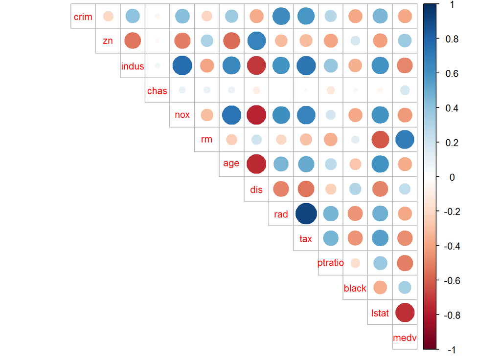

### Scaling the data

Before we begin our analysis, we shall standardise the dataset. This means that we assume normal distribution and adjust the numeric values of variables so that mean = 0, all values indicating a distance from the mean in units of standard deviation. The data now looks as follows (cf. with table above):

```
##       crim                 zn               indus
##  Min.   :-0.419367   Min.   :-0.48724   Min.   :-1.5563
##  1st Qu.:-0.410563   1st Qu.:-0.48724   1st Qu.:-0.8668
##  Median :-0.390280   Median :-0.48724   Median :-0.2109
##  Mean   : 0.000000   Mean   : 0.00000   Mean   : 0.0000
##  3rd Qu.: 0.007389   3rd Qu.: 0.04872   3rd Qu.: 1.0150
##  Max.   : 9.924110   Max.   : 3.80047   Max.   : 2.4202
##       chas              nox                rm               age
##  Min.   :-0.2723   Min.   :-1.4644   Min.   :-3.8764   Min.   :-2.3331
##  1st Qu.:-0.2723   1st Qu.:-0.9121   1st Qu.:-0.5681   1st Qu.:-0.8366
##  Median :-0.2723   Median :-0.1441   Median :-0.1084   Median : 0.3171
##  Mean   : 0.0000   Mean   : 0.0000   Mean   : 0.0000   Mean   : 0.0000
##  3rd Qu.:-0.2723   3rd Qu.: 0.5981   3rd Qu.: 0.4823   3rd Qu.: 0.9059
##  Max.   : 3.6648   Max.   : 2.7296   Max.   : 3.5515   Max.   : 1.1164
##       dis               rad               tax             ptratio
##  Min.   :-1.2658   Min.   :-0.9819   Min.   :-1.3127   Min.   :-2.7047
##  1st Qu.:-0.8049   1st Qu.:-0.6373   1st Qu.:-0.7668   1st Qu.:-0.4876
##  Median :-0.2790   Median :-0.5225   Median :-0.4642   Median : 0.2746
##  Mean   : 0.0000   Mean   : 0.0000   Mean   : 0.0000   Mean   : 0.0000
##  3rd Qu.: 0.6617   3rd Qu.: 1.6596   3rd Qu.: 1.5294   3rd Qu.: 0.8058
##  Max.   : 3.9566   Max.   : 1.6596   Max.   : 1.7964   Max.   : 1.6372
##      black             lstat              medv
##  Min.   :-3.9033   Min.   :-1.5296   Min.   :-1.9063
##  1st Qu.: 0.2049   1st Qu.:-0.7986   1st Qu.:-0.5989
##  Median : 0.3808   Median :-0.1811   Median :-0.1449
##  Mean   : 0.0000   Mean   : 0.0000   Mean   : 0.0000
##  3rd Qu.: 0.4332   3rd Qu.: 0.6024   3rd Qu.: 0.2683
##  Max.   : 0.4406   Max.   : 3.5453   Max.   : 2.9865
```

Before continuing, we shall modify the variable *crim* into a categorical factor variable based on its quantiles, seen above as its values for Min, 1st Qu., Median, 3rd Qu., and Max. The variable (renamed *crime*) now has the following factors and observations per factor:

```
##
##      low  med_low med_high     high
##      127      126      126      127
```

We shall also divide the dataset into a testing and training set. The training set will consist of a sample of 80 % of the whole dataset, the testing set the remaining 20 %.

```
##        zn               indus               chas
##  Min.   :-0.48724   Min.   :-1.44115   Min.   :-0.27233
##  1st Qu.:-0.48724   1st Qu.:-0.80124   1st Qu.:-0.27233
##  Median :-0.48724   Median :-0.16425   Median :-0.27233
##  Mean   :-0.04481   Mean   : 0.09475   Mean   :-0.04074
##  3rd Qu.:-0.48724   3rd Qu.: 1.01499   3rd Qu.:-0.27233
##  Max.   : 3.58609   Max.   : 2.42017   Max.   : 3.66477
##       nox                 rm               age               dis
##  Min.   :-1.33499   Min.   :-3.0552   Min.   :-2.0809   Min.   :-1.2428
##  1st Qu.:-0.67912   1st Qu.:-0.6150   1st Qu.:-0.5595   1st Qu.:-0.8948
##  Median :-0.06641   Median :-0.2279   Median : 0.5622   Median :-0.4665
##  Mean   : 0.09943   Mean   :-0.1362   Mean   : 0.1445   Mean   :-0.1175
##  3rd Qu.: 0.89150   3rd Qu.: 0.3218   3rd Qu.: 0.9201   3rd Qu.: 0.3131
##  Max.   : 2.72965   Max.   : 3.4434   Max.   : 1.1164   Max.   : 3.2841
##       rad               tax              ptratio
##  Min.   :-0.9819   Min.   :-1.30676   Min.   :-2.51994
##  1st Qu.:-0.6373   1st Qu.:-0.66595   1st Qu.:-0.74160
##  Median :-0.5225   Median :-0.06074   Median : 0.34387
##  Mean   : 0.1441   Mean   : 0.17648   Mean   : 0.05722
##  3rd Qu.: 1.6596   3rd Qu.: 1.52941   3rd Qu.: 0.80578
##  Max.   : 1.6596   Max.   : 1.79642   Max.   : 1.26768
##      black              lstat               medv              crime
##  Min.   :-3.82271   Min.   :-1.42599   Min.   :-1.8411   low     :25
##  1st Qu.: 0.20930   1st Qu.:-0.71496   1st Qu.:-0.8734   med_low :23
##  Median : 0.37692   Median :-0.07955   Median :-0.2482   med_high:23
##  Mean   : 0.06538   Mean   : 0.14009   Mean   :-0.1427   high    :31
##  3rd Qu.: 0.43832   3rd Qu.: 0.73931   3rd Qu.: 0.2411
##  Max.   : 0.44062   Max.   : 2.70785   Max.   : 2.9865
```

## Linear Discriminant Analysis

Linear Discriminant Analysis (LDA) is a classification method for continuous normally distributed classes such as in our scaled dataset in this analysis. Using *crime* as our target variable, we shall use LDA on our training set so as to later test it on the testing set

```
## Call:
## lda(crime ~ ., data = train)
##
## Prior probabilities of groups:
##       low   med_low  med_high      high
## 0.2524752 0.2549505 0.2549505 0.2376238
##
## Group means:
##                  zn      indus        chas        nox         rm
## low       0.9989570 -0.8995585 -0.07933396 -0.9018296  0.4231140
## med_low  -0.1134182 -0.3228601 -0.11943197 -0.5828620 -0.1323670
## med_high -0.3773415  0.1717506  0.30103504  0.3970046  0.1360055
## high     -0.4872402  1.0172418 -0.06727176  1.0519601 -0.3087697
##                 age        dis        rad        tax     ptratio
## low      -0.9004439  0.8913771 -0.7015101 -0.7465738 -0.44000757
## med_low  -0.3827139  0.3870894 -0.5481298 -0.5143880 -0.04089863
## med_high  0.3852904 -0.3756913 -0.4254780 -0.3313739 -0.30638211
## high      0.8004725 -0.8344236  1.6368728  1.5131579  0.77931510
##               black        lstat         medv
## low       0.3738338 -0.749274075  0.518975972
## med_low   0.3192679 -0.148322451 -0.002089146
## med_high  0.1011047  0.002616464  0.228988234
## high     -0.9176855  0.803591910 -0.643261140
##
## Coefficients of linear discriminants:
##                 LD1          LD2         LD3
## zn       0.07129707  0.680323502 -1.01765475
## indus    0.09756863 -0.162598613  0.27665399
## chas    -0.11753222 -0.094798652 -0.08445712
## nox      0.29454698 -0.859622328 -1.18639518
## rm      -0.12171489 -0.092081838 -0.17810408
## age      0.21214263 -0.290836681 -0.08964732
## dis     -0.08612086 -0.257146288  0.25065183
## rad      3.34931586  0.928260982  0.04003724
## tax      0.04999816  0.009630337  0.37865072
## ptratio  0.07514237 -0.029462380 -0.28813257
## black   -0.11679755  0.018776262  0.13799046
## lstat    0.15558438 -0.195366284  0.29279807
## medv     0.18571906 -0.420372002 -0.21858795
##
## Proportion of trace:
##    LD1    LD2    LD3
## 0.9484 0.0386 0.0129
```

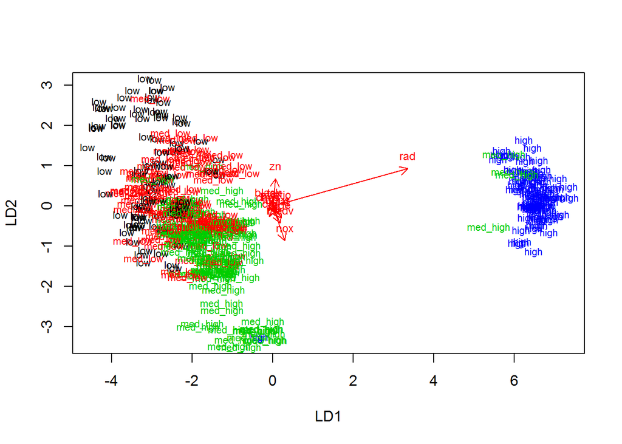

### Predicting classes in test data

Based on the classification data of the LDA above, we shall classify the observations of the test data, i.e. we are testing the predictive accuracy of the LDA on data not part of the model’s training data. The results of the prediction are as follows:

```
##           predicted
## correct    low med_low med_high high
##   low       14       9        2    0
##   med_low    5      12        6    0
##   med_high   0       8       13    2
##   high       0       0        0   31
```

## Distances

```r
data('Boston')
boston_scaled <- scale(Boston)
```

```
## [1] "Euclidean distance"
```

[output not shown]

```
## [1] "Manhattan distance"
```

```
##    Min. 1st Qu.  Median    Mean 3rd Qu.    Max.
##  0.2849  8.8390 13.0300 13.8700 18.1000 46.8900
```

Let us visualise the k-means of the dataset. Here the optimal number of clusters is determined by looking at the total of *within cluster sum of squares* (WCSS), namely, where the line in a line plot drops rapidly.

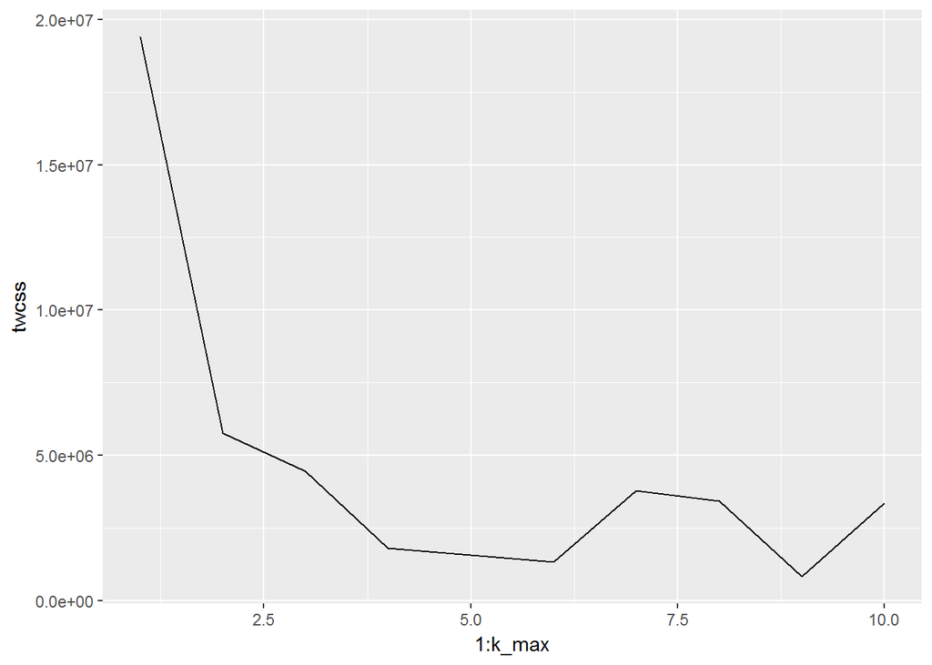

Based on the above, we select 2 as the optimal number of clusters. Visualised, the clusters appear as follows

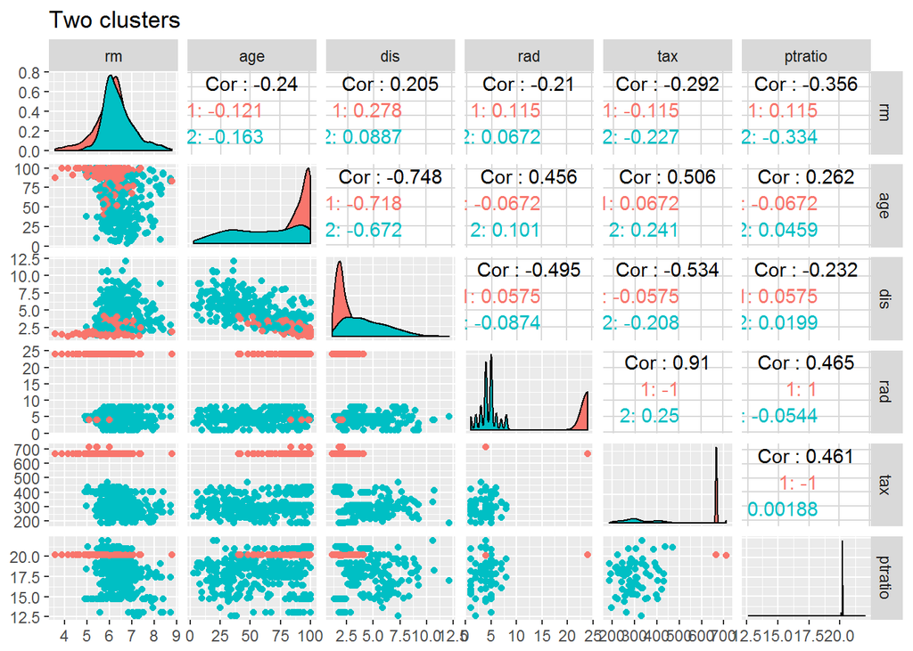

## Super-bonus

We shall create a 3D-plot of the data across the three linear dimensions, setting the colour to represent *crime* quantiles.

```
## [1] 404  13
```

```
## [1] 13  3
```

[interactive chart not shown]

Looking at the same model with color signifying the clusters:

```
## [1] 404  13
```

```
## [1] 13  3
```

[interactive chart not shown]